# Hydrochemical analysis of mid-low sections from North Patagonia Rivers, Argentina (2014-2015)

Vélez-Agudelo Camilo

18/2/2021

# **Exploratory Data Analysis**

## Complete Data

These data base include measurements of physical and chemical variables in coastal and inlet sites of three river from Northern Patagonia, Argentina. The measurements were made in the austral summer and winter of 2014 and 2015.

```r
varam <- readRDS("data.rds") ##original data##
```

Code to data filtered by summer and winter

```r
varam.inland <- varam[-c(1:6, 31:36, 67:76), -c(6, 7)]

varam.summer <- varam.inland %>%
    filter(Season == "summer") ##summer data##

varam.winter <- varam.inland[-c(2, 20),] %>%
    filter(Season == "winter")##winter data##
```

Physical and hidrochemical data (summer and winter) from Northen Patagonia River

| River | Site | Season | pH | Conductivity | Turbidity | D.Oxygen | Temperature | Salinity | HCO3 | Cl | Hardness | Ca | Mg | SO4 | Na | K | SiO2 | NO3 |
| --- | --- | --- | --- | --- | --- | --- | --- | --- | --- | --- | --- | --- | --- | --- | --- | --- | --- | --- |
| Colorado | RC01 | summer | 8.29 | 20.10 | 10.0 | 0.08 | 22.15 | 12.10 | 227.0 | 5065.0 | 2110.0 | 780 | 38.40 | 1770 | 2650 | 50.0 | 13.40 | 0.3 |
| Colorado | RC01 | winter | NA | NA | NA | NA | NA | NA | NA | NA | NA | NA | NA | NA | NA | NA | NA | NA |
| Colorado | RC02 | summer | 8.24 | 16.60 | 10.0 | 0.07 | 20.45 | 9.80 | 386.0 | 5021.0 | 2005.0 | 230 | 343.00 | 1590 | 2600 | 140.0 | 17.80 | 10.4 |
| Colorado | RC02 | winter | NA | NA | NA | NA | NA | NA | NA | NA | NA | NA | NA | NA | NA | NA | NA | NA |
| Colorado | RC03 | summer | 8.85 | 11.30 | 10.0 | 0.19 | 21.55 | 6.40 | 387.0 | 2554.0 | 1814.0 | 400 | 196.00 | 1220 | 1350 | 600.0 | 23.20 | 4.3 |
| Colorado | RC03 | winter | NA | NA | NA | NA | NA | NA | NA | NA | NA | NA | NA | NA | NA | NA | NA | NA |
| Colorado | RC04 | summer | 7.95 | 1.51 | 10.0 | 0.10 | 20.60 | 0.65 | 235.0 | 194.0 | 681.0 | 97 | 106.00 | 480 | 160 | 8.0 | 7.88 | 4.6 |
| Colorado | RC04 | winter | NA | NA | NA | NA | NA | NA | NA | NA | NA | NA | NA | NA | NA | NA | NA | NA |
| Colorado | RC05 | summer | 7.36 | 1.26 | 10.0 | 0.09 | 25.70 | 0.50 | 205.0 | 174.0 | 777.0 | 89 | 133.00 | 260 | 90 | 5.0 | 7.58 | 1.5 |
| Colorado | RC05 | winter | 7.57 | 2.07 | 10.0 | 0.38 | 8.40 | 0.90 | 129.0 | 326.0 | 1000.0 | 132 | 160.80 | 670 | 160 | 3.0 | 7.05 | 4.8 |
| Colorado | RC06 | summer | 9.39 | 1.33 | 152.5 | 0.22 | 22.60 | 0.60 | 194.0 | 238.0 | 565.0 | 91 | 81.00 | 315 | 95 | 1.6 | 17.00 | 1.0 |
| Colorado | RC06 | winter | 8.54 | 2.07 | 10.0 | 0.22 | 7.85 | 0.90 | 136.0 | 297.0 | 790.0 | 96 | 132.00 | 530 | 140 | 4.0 | 9.67 | 8.1 |
| Colorado | RC07 | summer | 9.36 | 0.13 | 177.0 | 0.26 | 22.50 | 0.60 | 161.0 | 204.0 | 487.0 | 75 | 71.80 | 230 | 87 | 3.3 | 12.90 | 1.0 |
| Colorado | RC07 | winter | 8.43 | 2.08 | 10.0 | 0.20 | 6.55 | 0.90 | 136.0 | 326.0 | 756.0 | 80 | 133.40 | 410 | 160 | 3.0 | 8.92 | 0.5 |
| Colorado | RC08 | summer | 7.79 | 1.41 | 10.0 | 0.03 | 24.05 | 0.60 | 380.0 | 156.0 | 395.0 | 89 | 41.40 | 390 | 190 | 5.0 | 7.88 | 0.5 |
| Colorado | RC08 | winter | 8.49 | 2.09 | 10.0 | 0.21 | 5.95 | 0.90 | 151.0 | 286.0 | 417.0 | 70 | 58.10 | 560 | 280 | 6.0 | 10.00 | 0.5 |
| Colorado | RC09 | summer | 9.29 | 1.27 | 162.5 | 0.18 | 20.00 | 0.50 | 118.0 | 223.0 | 534.0 | 79 | 80.70 | 240 | 90 | 1.6 | 15.70 | 0.5 |
| Colorado | RC09 | winter | 8.51 | 2.09 | 10.0 | 0.21 | 5.65 | 0.90 | 189.0 | 337.0 | 546.0 | 182 | 22.00 | 570 | 370 | 3.5 | 3.04 | 4.1 |
| Colorado | RC10 | summer | 7.93 | 1.40 | 10.0 | 0.07 | 22.35 | 0.60 | 113.6 | 222.0 | 576.0 | 85 | 87.40 | 320 | 90 | 3.0 | 9.70 | 1.1 |
| Colorado | RC10 | winter | 8.90 | 2.05 | 10.0 | 0.23 | 5.55 | 0.90 | 136.0 | 268.0 | 500.0 | 112 | 53.00 | 470 | 180 | 5.5 | 2.55 | 4.4 |
| Colorado | RC11 | summer | 9.05 | 1.33 | 74.5 | -0.11 | 27.45 | 0.60 | 174.0 | 256.0 | 467.0 | 120 | 40.08 | 225 | 92 | 3.2 | 12.50 | 2.7 |
| Colorado | RC11 | winter | 8.08 | 2.04 | 10.0 | 0.15 | 7.90 | 0.90 | 220.0 | 320.0 | 477.0 | 142 | 29.30 | 410 | 230 | 8.5 | 5.50 | 1.9 |
| Colorado | RC12 | summer | 8.60 | 1.42 | 10.0 | 0.10 | 24.20 | 0.60 | 227.0 | 152.0 | 476.0 | 100 | 54.20 | 440 | 160 | 4.0 | 8.04 | 3.4 |
| Colorado | RC12 | winter | 8.18 | 2.00 | 10.0 | 0.17 | 9.35 | 0.90 | 106.0 | 307.0 | 842.0 | 111 | 136.00 | 530 | 140 | 3.0 | 6.62 | 8.5 |
| Colorado | RC13 | summer | 7.62 | 1.31 | 10.0 | 0.07 | 21.40 | 0.50 | 227.0 | 148.0 | 508.0 | 90 | 68.00 | 290 | 90 | 2.0 | 6.74 | 0.3 |
| Colorado | RC13 | winter | NA | NA | NA | NA | NA | NA | NA | NA | NA | NA | NA | NA | NA | NA | NA | NA |
| Colorado | RC14 | summer | 7.83 | 1.25 | 10.0 | 0.10 | 24.05 | 0.50 | 219.0 | 148.0 | 474.0 | 86 | 62.10 | 270 | 160 | 4.0 | 6.61 | 0.3 |
| Colorado | RC14 | winter | 8.45 | 1.49 | 10.0 | 0.19 | 5.10 | 0.60 | 122.0 | 200.0 | 447.0 | 100 | 47.30 | 228 | 50 | 8.0 | 4.02 | 6.2 |
| Colorado | RC15 | summer | 7.97 | 1.24 | 10.0 | 0.08 | 21.20 | 0.50 | 250.0 | 156.0 | 470.0 | 84 | 62.40 | 350 | 150 | 1.0 | 7.07 | 5.4 |
| Colorado | RC15 | winter | 8.88 | 1.40 | 10.0 | 0.11 | 10.75 | 0.60 | 189.0 | 183.0 | 452.0 | 134 | 28.08 | 240 | 68 | 2.8 | 5.62 | 1.2 |

[output cut: 70 more lines]

Statistical summary of physical and chemical variables (complete data)

|  | pH | Conductivity | Turbidity | D.Oxygen | Temperature | Salinity | HCO3 | Cl | Hardness | Ca | Mg | SO4 | Na | K | SiO2 | NO3 |
| --- | --- | --- | --- | --- | --- | --- | --- | --- | --- | --- | --- | --- | --- | --- | --- | --- |
| nbr.val | 95.00 | 95.00 | 95.00 | 95.00 | 95.00 | 95.00 | 95.00 | 95.00 | 95.00 | 95.00 | 95.00 | 95.00 | 95.00 | 95.00 | 95.00 | 95.00 |
| nbr.null | 0.00 | 0.00 | 0.00 | 0.00 | 0.00 | 45.00 | 0.00 | 0.00 | 0.00 | 0.00 | 0.00 | 0.00 | 0.00 | 0.00 | 0.00 | 0.00 |
| nbr.na | 5.00 | 5.00 | 5.00 | 5.00 | 5.00 | 5.00 | 5.00 | 5.00 | 5.00 | 5.00 | 5.00 | 5.00 | 5.00 | 5.00 | 5.00 | 5.00 |
| min | 7.36 | 0.07 | 7.00 | -1.18 | 5.10 | 0.00 | 23.00 | 10.90 | 93.50 | 2.00 | 15.60 | 13.00 | 2.00 | 0.20 | 0.50 | 0.10 |
| max | 10.37 | 28.30 | 999.00 | 1.40 | 27.45 | 17.10 | 387.00 | 9406.00 | 6513.00 | 780.00 | 1323.10 | 1770.00 | 4800.00 | 600.00 | 40.70 | 22.50 |
| range | 3.01 | 28.23 | 992.00 | 2.58 | 22.35 | 17.10 | 364.00 | 9395.10 | 6419.50 | 778.00 | 1307.50 | 1757.00 | 4798.00 | 599.80 | 40.20 | 22.40 |
| sum | 822.37 | 254.49 | 12221.00 | 17.29 | 1424.50 | 137.85 | 15059.80 | 64684.30 | 47117.70 | 7790.00 | 6643.32 | 22058.00 | 34290.00 | 1596.90 | 1012.12 | 345.70 |
| median | 8.79 | 0.29 | 48.00 | 0.19 | 17.50 | 0.10 | 150.00 | 66.00 | 232.00 | 22.00 | 40.08 | 57.00 | 50.00 | 1.60 | 9.60 | 2.70 |
| mean | 8.66 | 2.68 | 128.64 | 0.18 | 14.99 | 1.45 | 158.52 | 680.89 | 495.98 | 82.00 | 69.93 | 232.19 | 360.95 | 16.81 | 10.65 | 3.64 |
| SE.mean | 0.07 | 0.60 | 22.01 | 0.02 | 0.70 | 0.36 | 7.35 | 172.23 | 79.80 | 15.10 | 14.25 | 38.37 | 88.78 | 6.94 | 0.74 | 0.39 |
| CI.mean.0.95 | 0.13 | 1.19 | 43.70 | 0.04 | 1.39 | 0.72 | 14.60 | 341.97 | 158.43 | 29.98 | 28.30 | 76.19 | 176.27 | 13.77 | 1.47 | 0.77 |
| var | 0.43 | 34.39 | 46010.70 | 0.05 | 46.53 | 12.46 | 5133.82 | 2818123.32 | 604888.68 | 21660.38 | 19299.12 | 139891.45 | 748780.86 | 4570.50 | 51.98 | 14.20 |
| std.dev | 0.65 | 5.86 | 214.50 | 0.22 | 6.82 | 3.53 | 71.65 | 1678.73 | 777.75 | 147.17 | 138.92 | 374.02 | 865.32 | 67.61 | 7.21 | 3.77 |
| coef.var | 0.08 | 2.19 | 1.67 | 1.21 | 0.45 | 2.43 | 0.45 | 2.47 | 1.57 | 1.79 | 1.99 | 1.61 | 2.40 | 4.02 | 0.68 | 1.04 |

### Histogram density plots

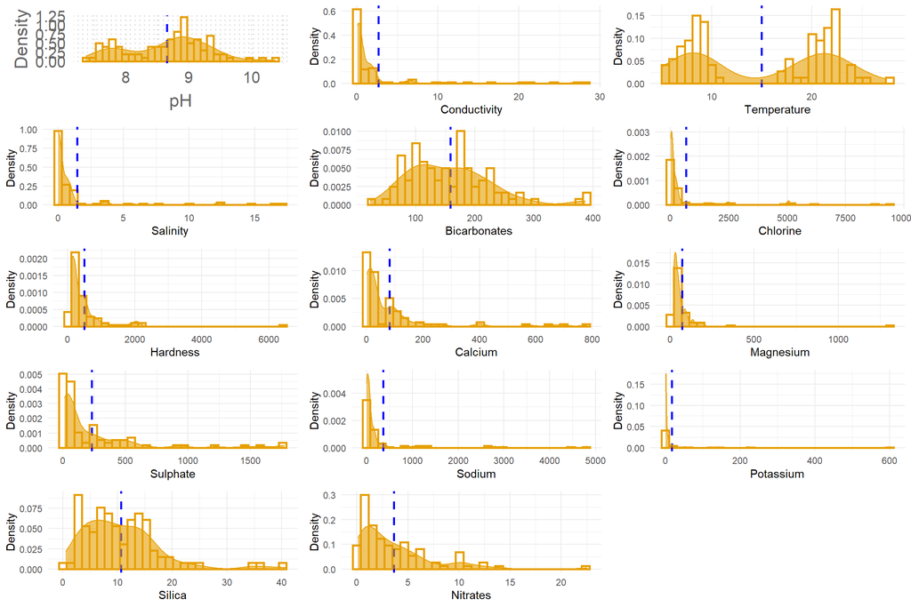

### Bean Plot

Beanplots of physical and hydrochemical variables measured in the Colorado, Negro and Chubut Rivers. The dotted line is the overall mean for each variables while the solid line indicates the mean value in each season.

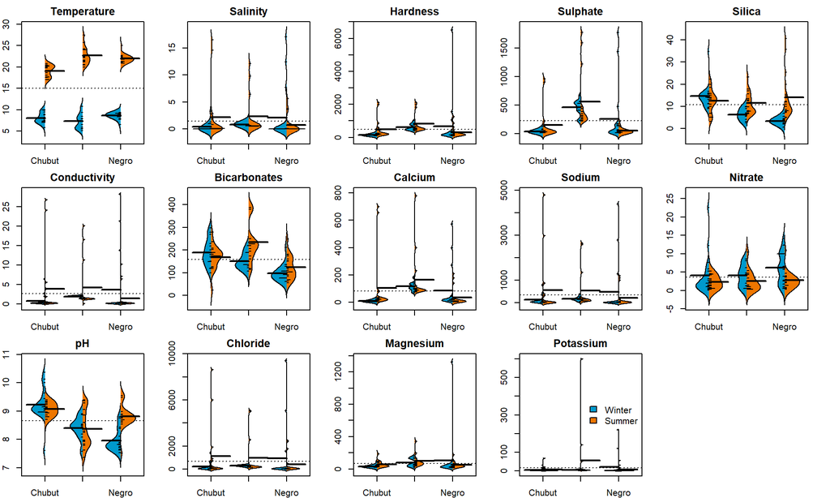

## Inland Areas

These data base include measurements of summer and winter taken in inland areas (to reduce the salinity effect the estuarine sites were remove from these analysis)

### Summary Summer Data

These data include only the summer measurements doing in the three rivers.

Statistical summary of physical and chemical variables measured in summer

|  | pH | Conductivity | Temperature | Salinity | HCO3 | Cl | Hardness | Ca | Mg | SO4 | Na | K | SiO2 | NO3 |
| --- | --- | --- | --- | --- | --- | --- | --- | --- | --- | --- | --- | --- | --- | --- |
| nbr.val | 39.00 | 39.00 | 39.00 | 39.00 | 39.00 | 39.00 | 39.00 | 39.00 | 39.00 | 39.00 | 39.00 | 39.00 | 39.00 | 39.00 |
| nbr.null | 0.00 | 0.00 | 0.00 | 19.00 | 0.00 | 0.00 | 0.00 | 0.00 | 0.00 | 0.00 | 0.00 | 0.00 | 0.00 | 0.00 |
| nbr.na | 0.00 | 0.00 | 0.00 | 0.00 | 0.00 | 0.00 | 0.00 | 0.00 | 0.00 | 0.00 | 0.00 | 0.00 | 0.00 | 0.00 |
| min | 7.36 | 0.07 | 17.00 | 0.00 | 55.60 | 18.20 | 93.50 | 2.00 | 16.80 | 13.00 | 2.00 | 0.30 | 3.20 | 0.30 |
| max | 9.39 | 1.51 | 27.45 | 0.65 | 380.00 | 475.00 | 777.00 | 120.00 | 133.00 | 480.00 | 190.00 | 17.00 | 40.70 | 10.90 |
| range | 2.03 | 1.44 | 10.45 | 0.65 | 324.40 | 456.80 | 683.50 | 118.00 | 116.20 | 467.00 | 188.00 | 16.70 | 37.50 | 10.60 |
| sum | 337.92 | 20.93 | 826.80 | 7.55 | 6357.80 | 4198.60 | 11640.10 | 1440.00 | 1931.20 | 4674.00 | 2189.00 | 85.20 | 455.50 | 86.80 |
| median | 8.79 | 0.28 | 21.30 | 0.10 | 174.00 | 58.50 | 202.00 | 20.00 | 40.20 | 37.00 | 30.00 | 1.20 | 10.00 | 1.50 |
| mean | 8.66 | 0.54 | 21.20 | 0.19 | 163.02 | 107.66 | 298.46 | 36.92 | 49.52 | 119.85 | 56.13 | 2.18 | 11.68 | 2.23 |
| SE.mean | 0.08 | 0.08 | 0.38 | 0.04 | 10.33 | 15.53 | 28.88 | 5.98 | 4.24 | 22.60 | 8.90 | 0.47 | 1.09 | 0.34 |
| CI.mean.0.95 | 0.17 | 0.17 | 0.77 | 0.08 | 20.91 | 31.44 | 58.47 | 12.11 | 8.58 | 45.75 | 18.01 | 0.94 | 2.21 | 0.68 |
| var | 0.28 | 0.27 | 5.62 | 0.06 | 4160.79 | 9407.02 | 32538.63 | 1396.39 | 699.92 | 19917.03 | 3088.33 | 8.45 | 46.53 | 4.39 |
| std.dev | 0.53 | 0.52 | 2.37 | 0.25 | 64.50 | 96.99 | 180.38 | 37.37 | 26.46 | 141.13 | 55.57 | 2.91 | 6.82 | 2.09 |
| coef.var | 0.06 | 0.96 | 0.11 | 1.31 | 0.40 | 0.90 | 0.60 | 1.01 | 0.53 | 1.18 | 0.99 | 1.33 | 0.58 | 0.94 |

Data transformed code:

```r
##As squared root##
varam.summer.sqrt <- apply(
  varam.summer[,-c(1:3)],
  2,
  sqrt
  )

varam.summer.sqrt <- as.data.frame(varam.summer.sqrt)
varam.summer.sqrt <- cbind(
  varam.summer[,c(1:3)],
  round(varam.summer.sqrt, digits = 2)
  )


##As logarithm except pH##
varam.summer.log <- apply(
  varam.summer[,-c(1:4)],
  2,
  log1p
  )

varam.summer.log <- as.data.frame(varam.summer.log)
varam.summer.log <- cbind(
  varam.summer[,c(1:4)],
  round(varam.summer.log, digits = 2)
  )
```

### Summary Winter Data

These data include only the winter measurements doing in the three rivers.

Statistical summary of physical and chemical variables measured in winter

|  | pH | Conductivity | Temperature | Salinity | HCO3 | Cl | Hardness | Ca | Mg | SO4 | Na | K | SiO2 | NO3 |
| --- | --- | --- | --- | --- | --- | --- | --- | --- | --- | --- | --- | --- | --- | --- |
| nbr.val | 37.00 | 37.00 | 37.00 | 37.00 | 37.00 | 37.00 | 37.00 | 37.00 | 37.00 | 37.00 | 37.00 | 37.00 | 37.00 | 37.00 |
| nbr.null | 0.00 | 0.00 | 0.00 | 26.00 | 0.00 | 0.00 | 0.00 | 0.00 | 0.00 | 0.00 | 0.00 | 0.00 | 0.00 | 0.00 |
| nbr.na | 0.00 | 0.00 | 0.00 | 0.00 | 0.00 | 0.00 | 0.00 | 0.00 | 0.00 | 0.00 | 0.00 | 0.00 | 0.00 | 0.00 |
| min | 7.53 | 0.11 | 5.10 | 0.00 | 60.60 | 10.90 | 97.50 | 2.00 | 15.60 | 17.00 | 7.00 | 0.20 | 2.00 | 0.10 |
| max | 9.44 | 2.09 | 10.75 | 0.90 | 229.00 | 337.00 | 1000.00 | 182.00 | 160.80 | 670.00 | 370.00 | 9.00 | 34.80 | 14.10 |
| range | 1.91 | 1.98 | 5.65 | 0.90 | 168.40 | 326.10 | 902.50 | 180.00 | 145.20 | 653.00 | 363.00 | 8.80 | 32.80 | 14.00 |
| sum | 308.79 | 24.23 | 292.80 | 8.50 | 4931.00 | 3856.70 | 10379.90 | 1521.00 | 1586.62 | 5947.00 | 2451.00 | 91.40 | 295.08 | 183.10 |
| median | 8.39 | 0.19 | 7.90 | 0.00 | 129.00 | 45.40 | 140.00 | 18.00 | 27.60 | 34.00 | 29.00 | 1.30 | 5.62 | 4.40 |
| mean | 8.35 | 0.65 | 7.91 | 0.23 | 133.27 | 104.24 | 280.54 | 41.11 | 42.88 | 160.73 | 66.24 | 2.47 | 7.98 | 4.95 |
| SE.mean | 0.10 | 0.13 | 0.21 | 0.06 | 7.72 | 18.98 | 39.85 | 8.21 | 6.05 | 33.42 | 14.00 | 0.38 | 1.07 | 0.65 |
| CI.mean.0.95 | 0.20 | 0.27 | 0.42 | 0.13 | 15.66 | 38.50 | 80.82 | 16.65 | 12.27 | 67.79 | 28.40 | 0.77 | 2.16 | 1.31 |
| var | 0.36 | 0.65 | 1.62 | 0.15 | 2206.90 | 13334.15 | 58760.85 | 2494.65 | 1354.31 | 41334.70 | 7255.63 | 5.37 | 41.98 | 15.45 |
| std.dev | 0.60 | 0.80 | 1.27 | 0.38 | 46.98 | 115.47 | 242.41 | 49.95 | 36.80 | 203.31 | 85.18 | 2.32 | 6.48 | 3.93 |
| coef.var | 0.07 | 1.23 | 0.16 | 1.66 | 0.35 | 1.11 | 0.86 | 1.22 | 0.86 | 1.26 | 1.29 | 0.94 | 0.81 | 0.79 |

Data transformed code:

```r
##As squared root##
varam.winter.sqrt <- apply(
  varam.winter[,-c(1:3)],
  2,
  sqrt
  )

varam.winter.sqrt <- as.data.frame(varam.winter.sqrt)
varam.winter.sqrt <- cbind(
  varam.winter[,c(1:3)],
  round(varam.winter.sqrt, digits = 2)
  )


##As logarithm except pH##
varam.winter.log <- apply(
  varam.winter[,-c(1:4)],
  2,
  log1p
  )

varam.winter.log <- as.data.frame(varam.winter.log)
varam.winter.log <- cbind(
  varam.winter[,c(1:4)],
  round(varam.winter.log, digits = 2)
  )
```

### Bean Plots

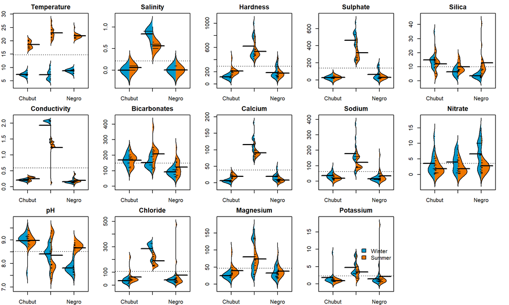

# **Multinormality Test**

## Complete Data

Data transformed code:

```r
##As squared root##
varam.sqrt <- apply(
  varam[complete.cases(varam), -c(1:3, 6:7)],
  2,
  sqrt
  )

varam.sqrt <- as.data.frame(varam.sqrt)
varam.sqrt <- cbind(
  varam[complete.cases(varam), c(1:3)],
  round(varam.sqrt, digits = 2)
  )


##As logarithm except pH##
varam.log <- apply(
  varam[complete.cases(varam), -c(1:4, 6:7)],
  2,
  log1p
  )

varam.log <- as.data.frame(varam.log)
varam.log <- cbind(
  varam[complete.cases(varam), c(1:4)],
  round(varam.log, digits = 2)
  )
```

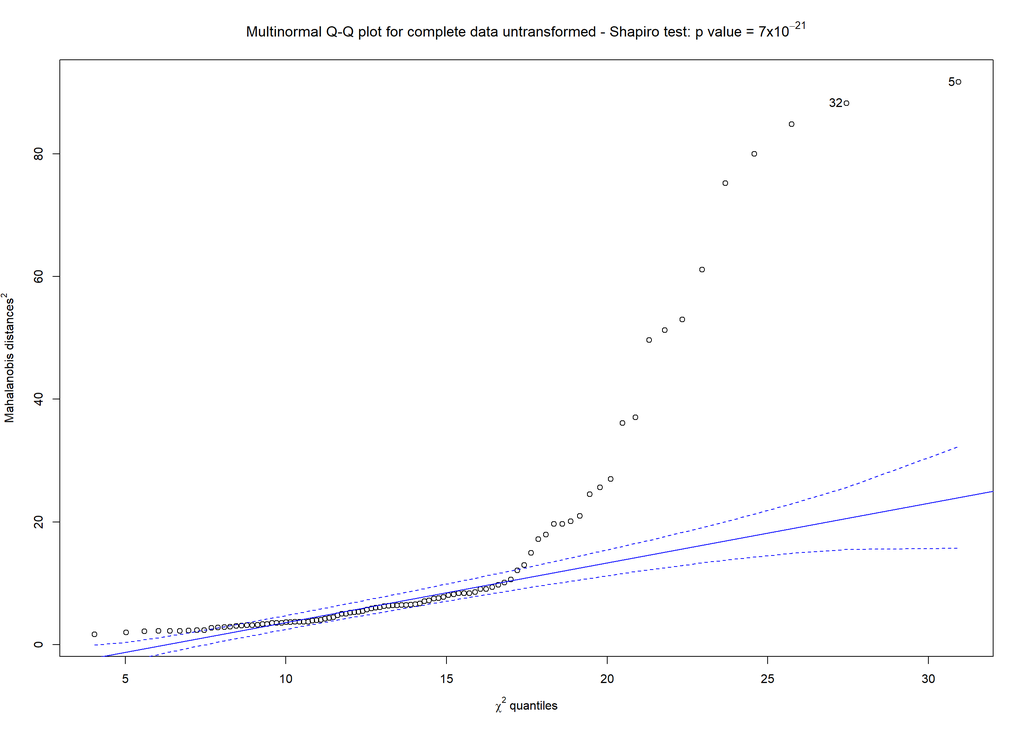

```
##  5 32
##  3 27
```

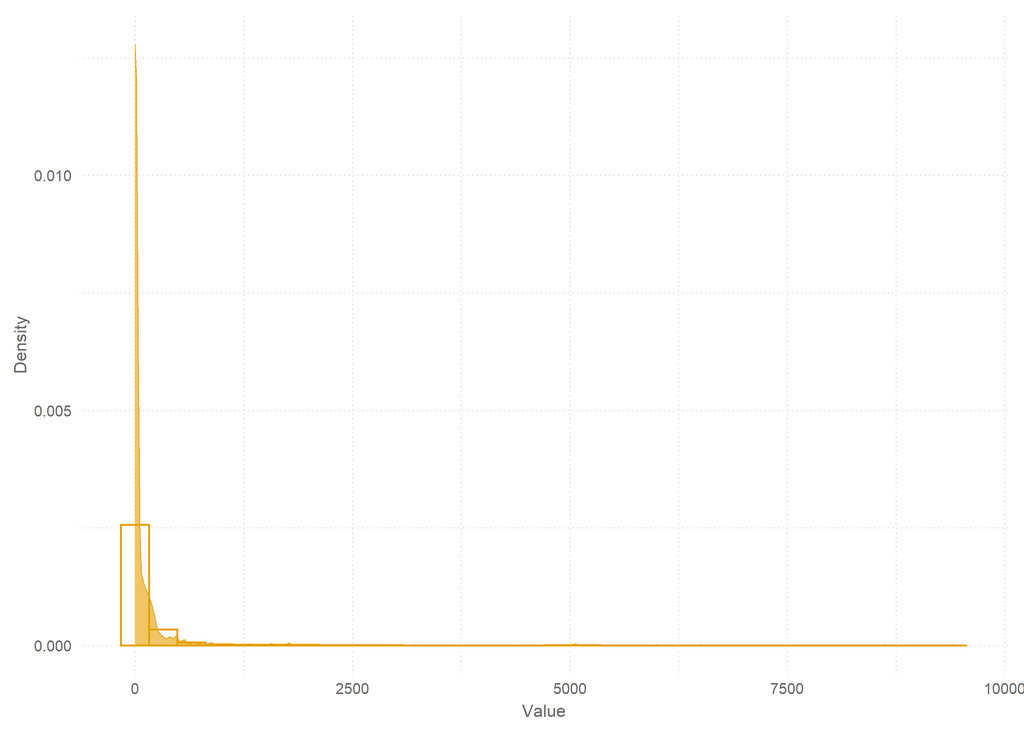

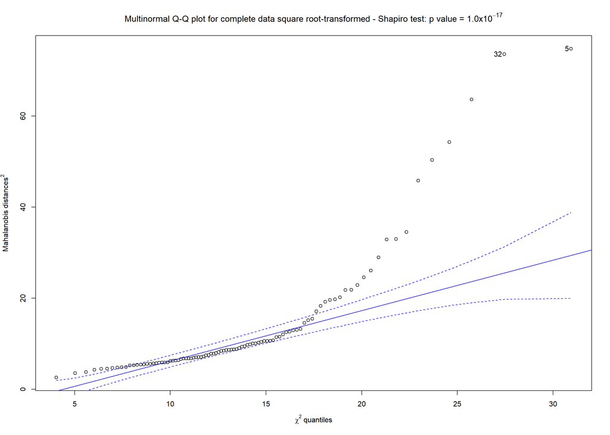

```
##  5 32
##  3 27
```

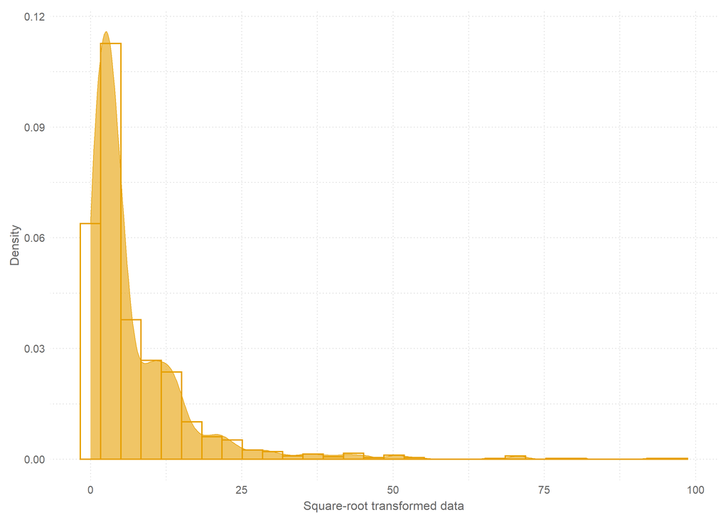

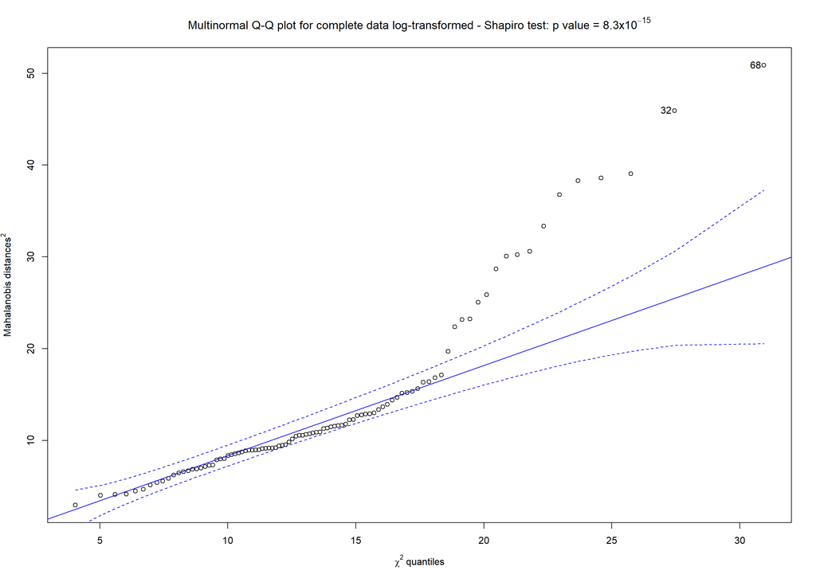

```
## 68 32
## 63 27
```

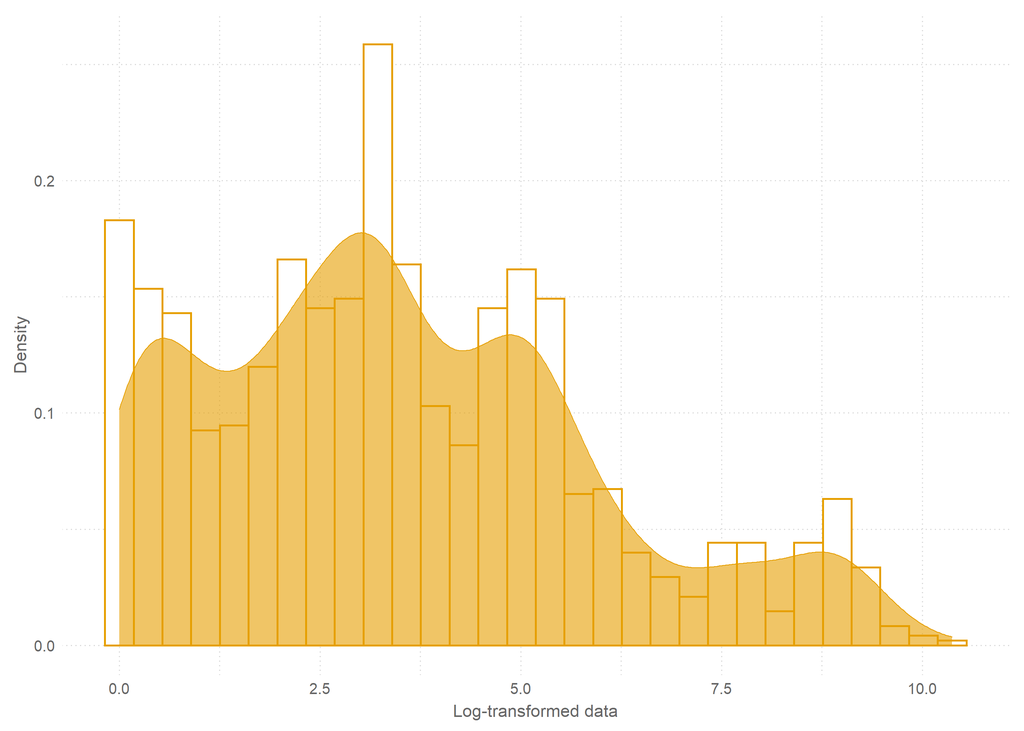

## Inland Summer Data

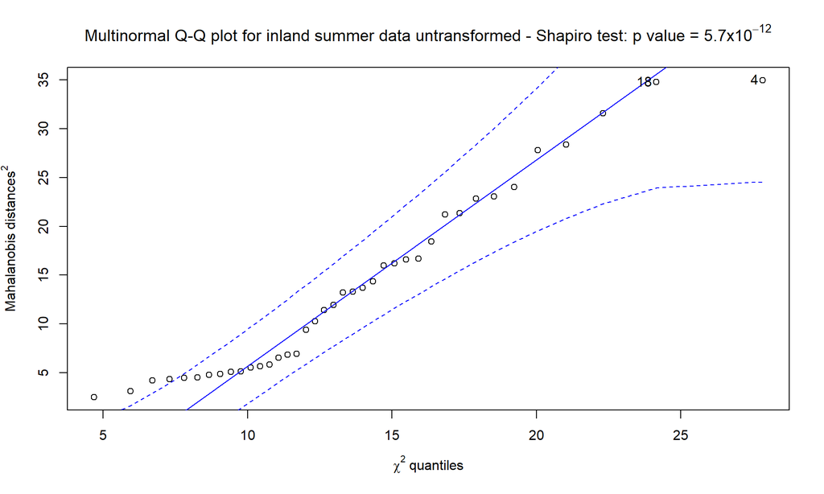

```
## [1]  4 18
```

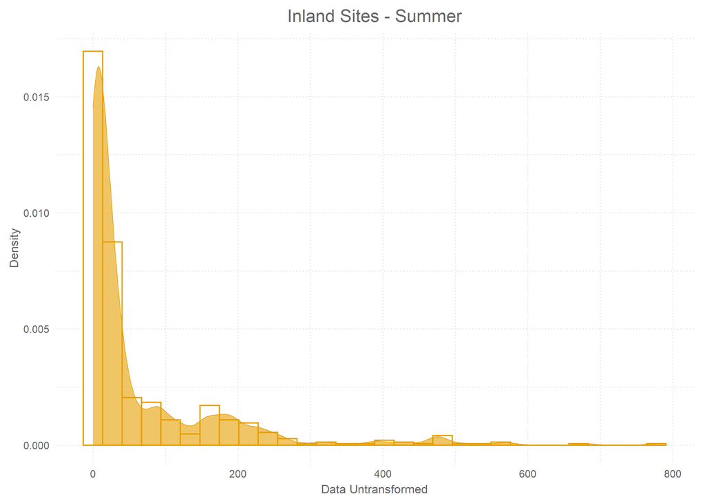

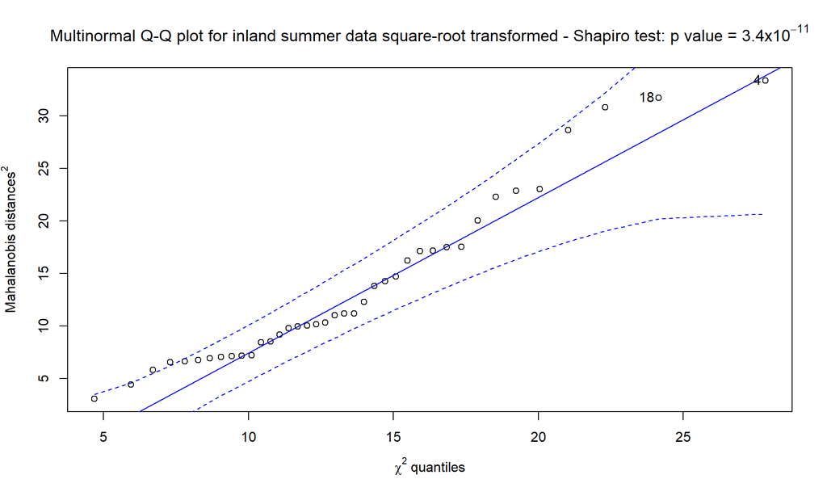

```
## [1]  4 18
```

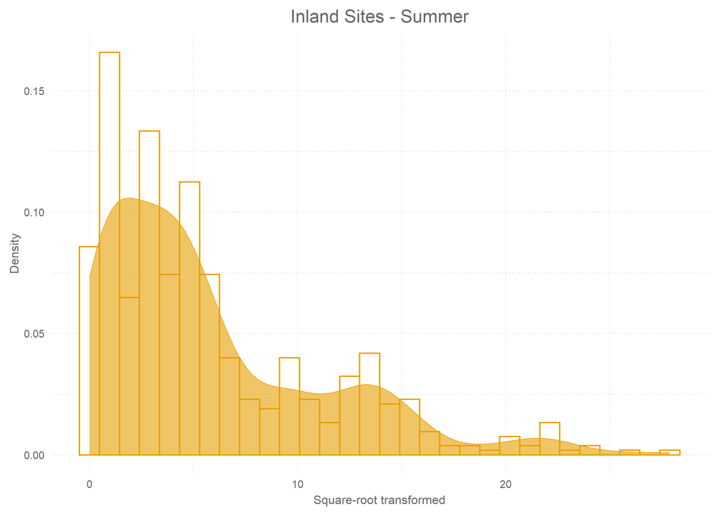

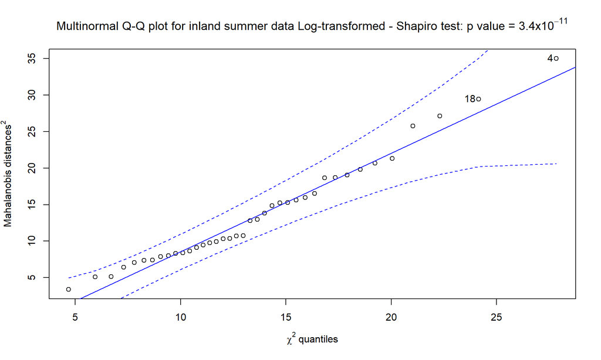

```
## [1]  4 18
```

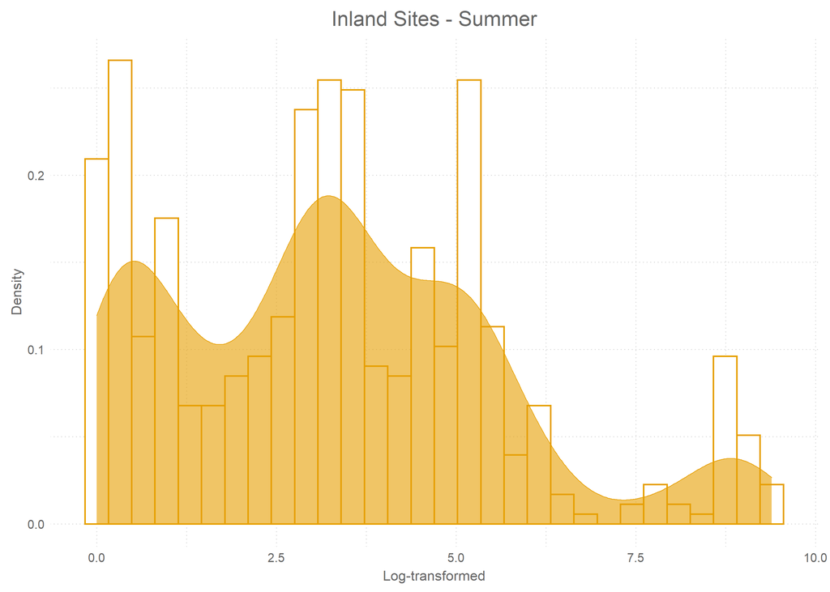

## Inland Winter Data

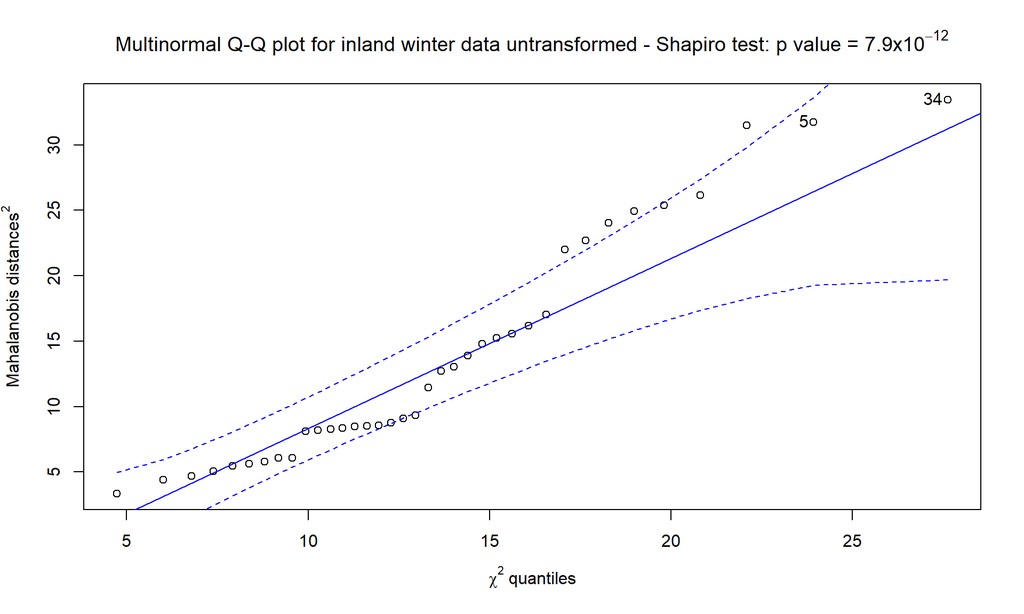

```
## [1] 34  5
```

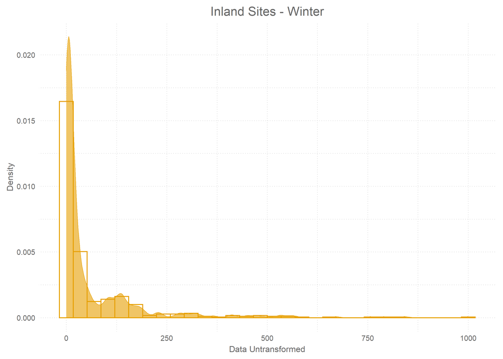

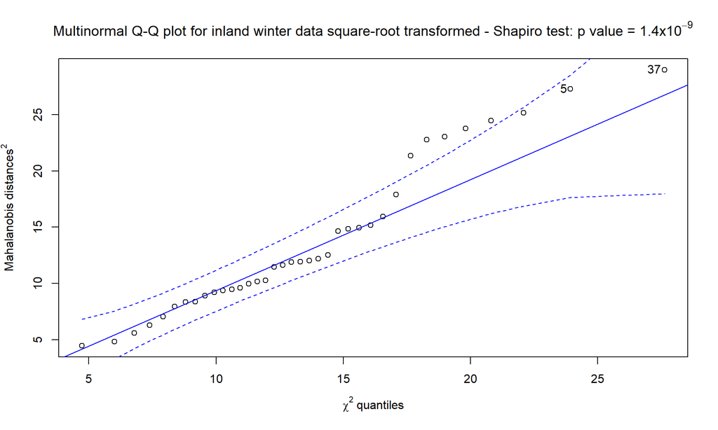

```
## [1] 37  5
```

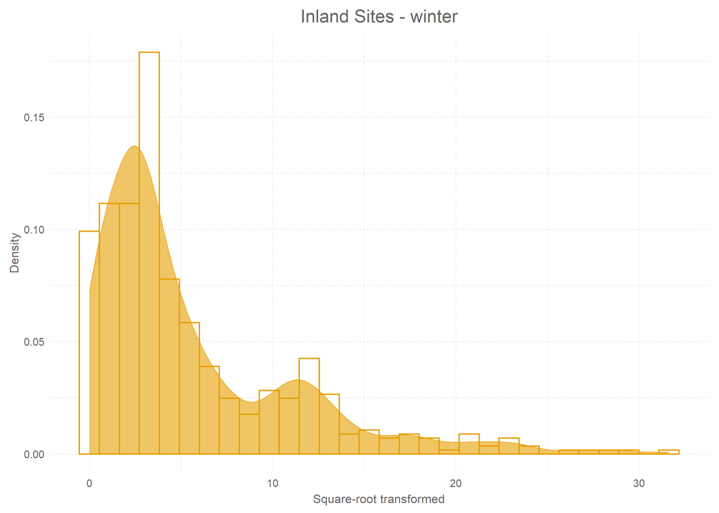

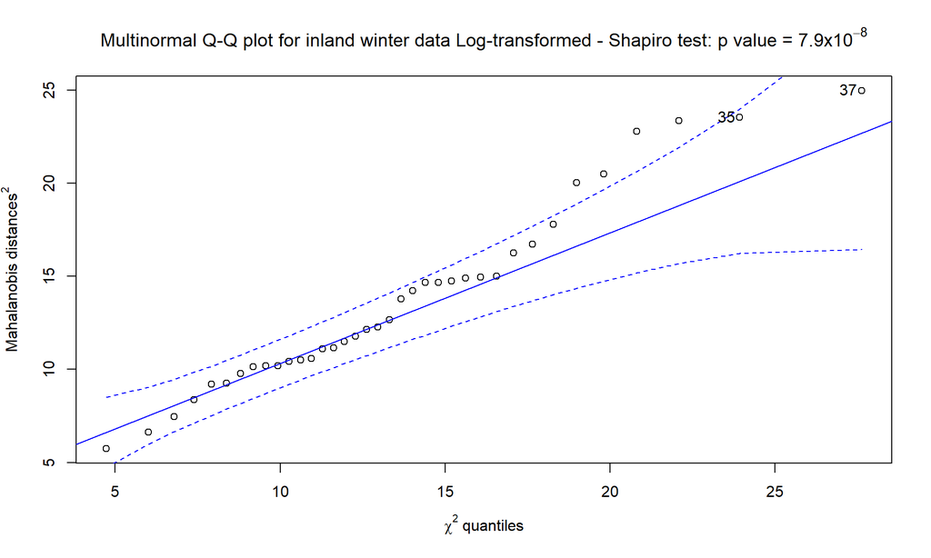

```
## [1] 37 35
```

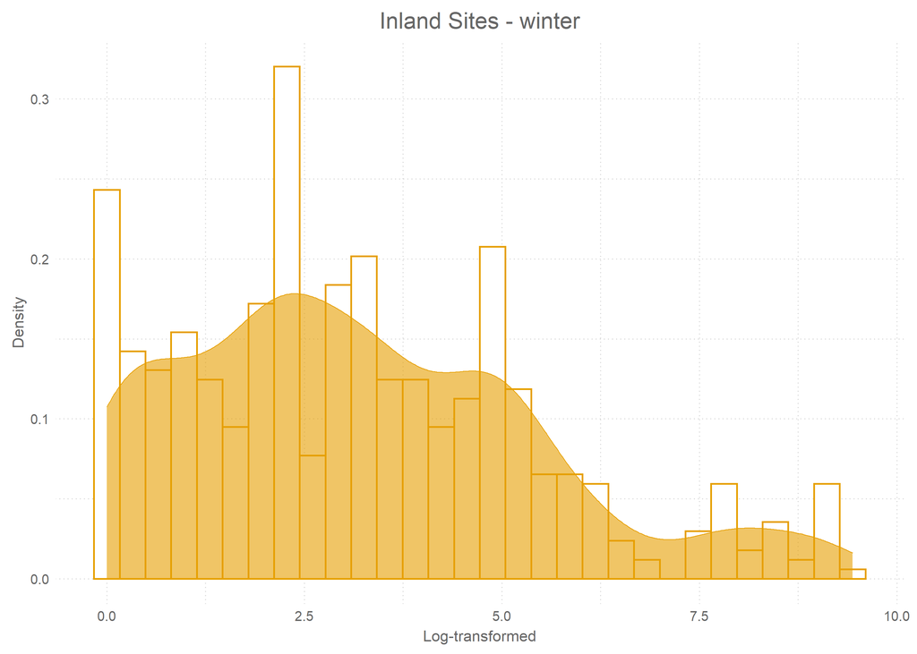

# **Correlation Analysis**

## Inland Summer Data

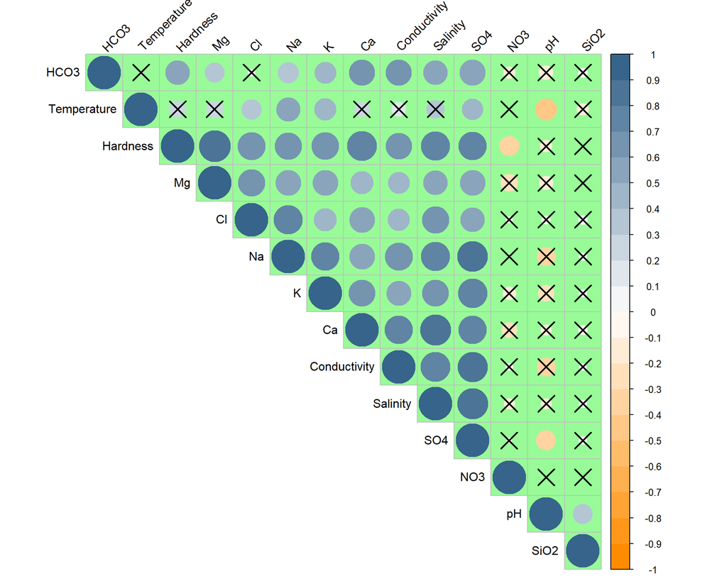

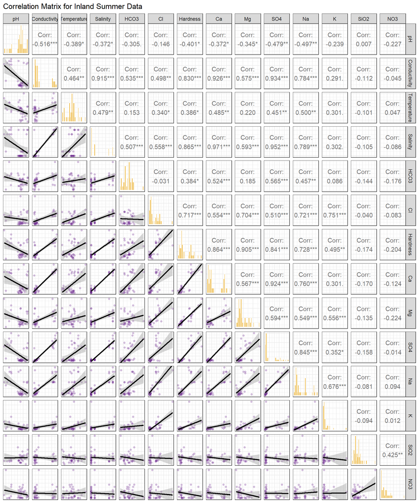

## Inland Winter Data

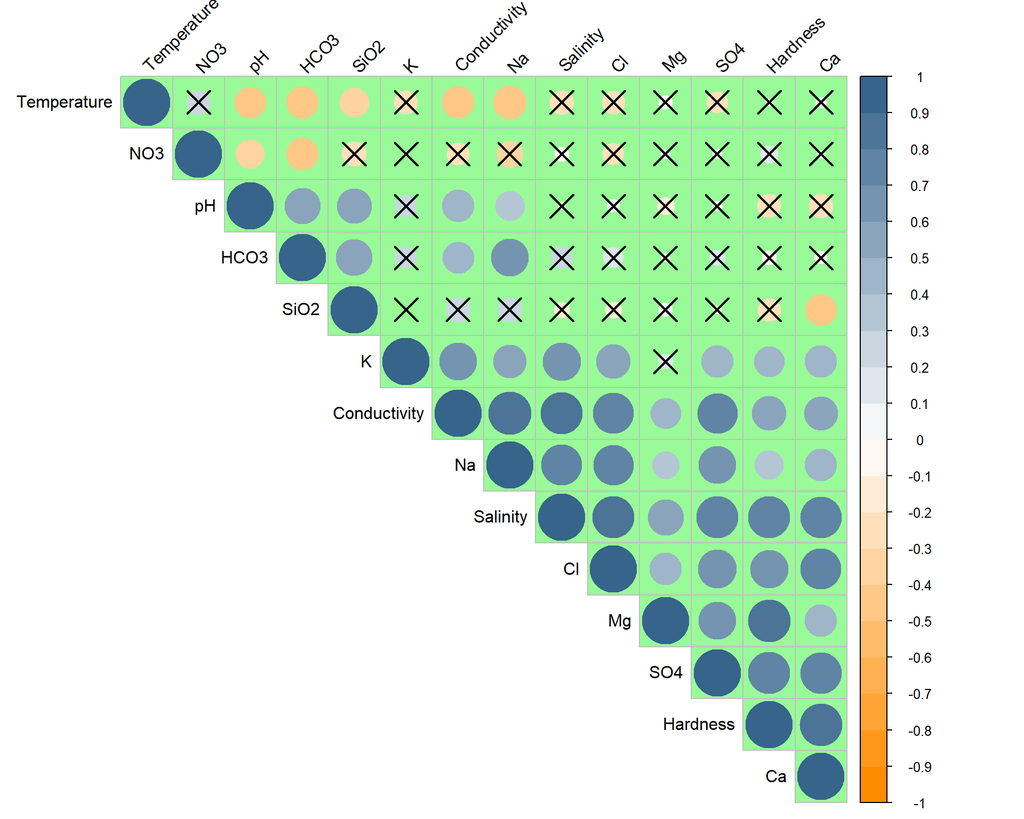

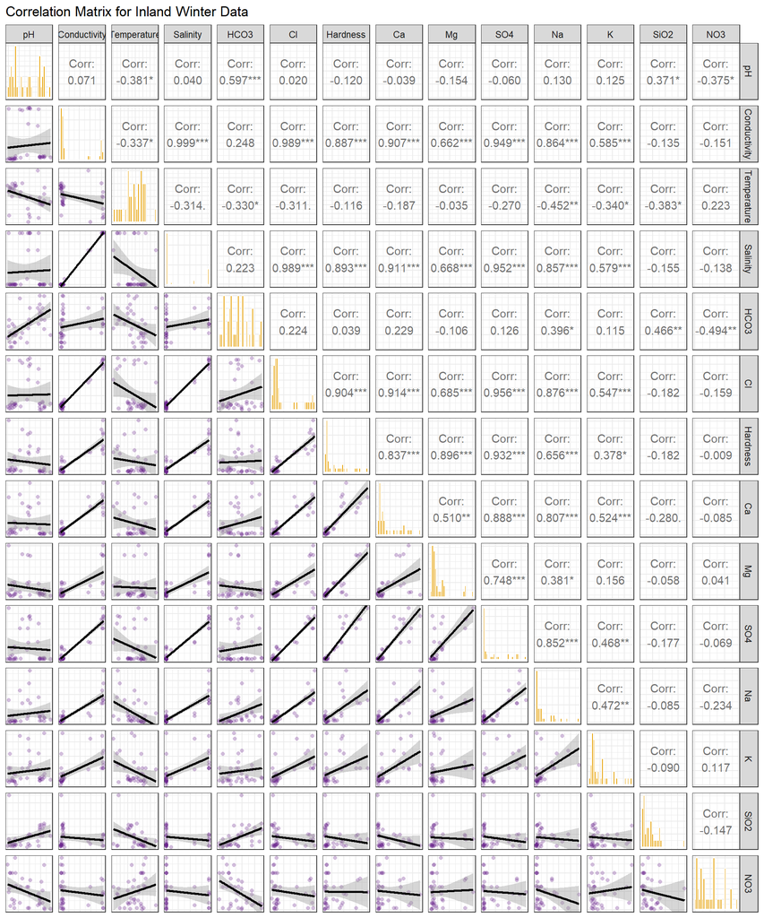

# **Kruskal-Wallis and Dunn’s Test**

## Inland Summer Data

Results of the Kruskal-Wallis and Dunn’s multiple comparisons test among rivers in relation to the physical and hydrochemical variables measured in inland sites during summer. In addition, see beanplots for inland summer data

Variable

.y.

group1

group2

n1

n2

statistic

p

p.adj

p.adj.signif

Ca

Value

Chubut

Colorado

12

12

2.9471112

0.0032076

0.0096227

Ca

Value

Chubut

Negro

12

15

-2.3624720

0.0181535

0.0544605

ns

Ca

Value

Colorado

Negro

12

15

-5.4690000

0.0000000

0.0000001

Cl

Value

Chubut

Colorado

12

12

3.2609642

0.0011103

0.0033310

Cl

Value

Chubut

Negro

12

15

-0.4910512

0.6233903

1.0000000

ns

Cl

Value

Colorado

Negro

12

15

-3.9284092

0.0000855

0.0002565

***

Conductivity

Value

Chubut

Colorado

12

12

2.6734877

0.0075067

0.0225201

Conductivity

Value

Chubut

Negro

12

15

-1.6397958

0.1010476

0.3031429

ns

Conductivity

Value

Colorado

Negro

12

15

-4.4578992

0.0000083

0.0000248

Hardness

Value

Chubut

Colorado

12

12

3.3664214

0.0007615

0.0022845

Hardness

Value

Chubut

Negro

12

15

-1.4647082

0.1430006

0.4290017

ns

Hardness

Value

Colorado

Negro

12

15

-5.0132279

0.0000005

0.0000016

HCO3

Value

Chubut

Colorado

12

12

1.1832674

0.2367032

0.7101095

ns

HCO3

Value

Chubut

Negro

12

15

-2.2753290

0.0228862

0.0686586

ns

HCO3

Value

Colorado

Negro

12

15

-3.5226024

0.0004273

0.0012820

K

Value

Chubut

Colorado

12

12

3.7710711

0.0001625

0.0004876

***

K

Value

Chubut

Negro

12

15

0.6341164

0.5260049

1.0000000

ns

K

Value

Colorado

Negro

12

15

-3.3409416

0.0008349

0.0025048

Mg

Value

Chubut

Colorado

12

12

3.1958244

0.0013943

0.0041830

Mg

Value

Chubut

Negro

12

15

-0.3151664

0.7526353

1.0000000

ns

Mg

Value

Colorado

Negro

12

15

-3.6838611

0.0002297

0.0006892

***

Na

Value

Chubut

Colorado

12

12

4.1493474

0.0000333

0.0001000

***

Na

Value

Chubut

Negro

12

15

0.4553282

0.6488731

1.0000000

ns

Na

Value

Colorado

Negro

12

15

-3.9184679

0.0000891

0.0002673

***

NO3

Value

Chubut

Colorado

12

12

-0.0538533

0.9570521

1.0000000

ns

NO3

Value

Chubut

Negro

12

15

1.1277574

0.2594224

0.7782671

ns

NO3

Value

Colorado

Negro

12

15

1.1845238

0.2362058

0.7086174

ns

pH

Value

Chubut

Colorado

12

12

-2.6238332

0.0086946

0.0260839

pH

Value

Chubut

Negro

12

15

-2.4259423

0.0152687

0.0458061

pH

Value

Colorado

Negro

12

15

0.3398207

0.7339915

1.0000000

ns

Salinity

Value

Chubut

Colorado

12

12

3.5977251

0.0003210

0.0009630

***

Salinity

Value

Chubut

Negro

12

15

-1.6928984

0.0904748

0.2714244

ns

Salinity

Value

Colorado

Negro

12

15

-5.4852337

0.0000000

0.0000001

SiO2

Value

Chubut

Colorado

12

12

-1.0030686

0.3158278

0.9474833

ns

SiO2

Value

Chubut

Negro

12

15

-0.5286636

0.5970389

1.0000000

ns

SiO2

Value

Colorado

Negro

12

15

0.5286636

0.5970389

1.0000000

ns

SO4

Value

Chubut

Colorado

12

12

4.2726468

0.0000193

0.0000579

SO4

Value

Chubut

Negro

12

15

0.1529581

0.8784313

1.0000000

ns

SO4

Value

Colorado

Negro

12

15

-4.3508071

0.0000136

0.0000407

Temperature

Value

Chubut

Colorado

12

12

4.6750161

0.0000029

0.0000088

Temperature

Value

Chubut

Negro

12

15

3.8875652

0.0001013

0.0003038

***

Temperature

Value

Colorado

Negro

12

15

-1.0403344

0.2981846

0.8945538

ns

## Inland Winter Data

Results of the Kruskal-Wallis and Dunn’s multiple comparisons test among rivers in relation to the physical and hydrochemical variables measured in inland sites during winter. In addition, see beanplot for inlanda winter data

Variable

.y.

group1

group2

n1

n2

statistic

p

p.adj

p.adj.signif

Ca

Value

Chubut

Colorado

12

10

5.3673513

0.0000001

0.0000002

Ca

Value

Chubut

Negro

12

15

2.7239865

0.0064499

0.0193497

Ca

Value

Colorado

Negro

10

15

-3.0451251

0.0023258

0.0069775

Cl

Value

Chubut

Colorado

12

10

4.2096273

0.0000256

0.0000767

Cl

Value

Chubut

Negro

12

15

0.4295924

0.6674921

1.0000000

ns

Cl

Value

Colorado

Negro

10

15

-4.0075472

0.0000614

0.0001841

***

Conductivity

Value

Chubut

Colorado

12

10

2.8932150

0.0038132

0.0114396

Conductivity

Value

Chubut

Negro

12

15

-2.2061162

0.0273759

0.0821276

ns

Conductivity

Value

Colorado

Negro

10

15

-5.1273351

0.0000003

0.0000009

Hardness

Value

Chubut

Colorado

12

10

5.1438793

0.0000003

0.0000008

Hardness

Value

Chubut

Negro

12

15

2.2906161

0.0219856

0.0659569

ns

Hardness

Value

Colorado

Negro

10

15

-3.2218769

0.0012735

0.0038206

HCO3

Value

Chubut

Colorado

12

10

-0.7204070

0.4712744

1.0000000

ns

HCO3

Value

Chubut

Negro

12

15

-4.3804195

0.0000118

0.0000355

HCO3

Value

Colorado

Negro

10

15

-3.4000616

0.0006737

0.0020211

K

Value

Chubut

Colorado

12

10

3.0970963

0.0019543

0.0058628

K

Value

Chubut

Negro

12

15

-0.7095069

0.4780100

1.0000000

ns

K

Value

Colorado

Negro

10

15

-3.9213593

0.0000881

0.0002642

***

Mg

Value

Chubut

Colorado

12

10

3.1760672

0.0014929

0.0044786

Mg

Value

Chubut

Negro

12

15

0.8470005

0.3969948

1.0000000

ns

Mg

Value

Colorado

Negro

10

15

-2.5275522

0.0114861

0.0344582

Na

Value

Chubut

Colorado

12

10

2.6515708

0.0080118

0.0240355

Na

Value

Chubut

Negro

12

15

-2.4455068

0.0144649

0.0433946

Na

Value

Colorado

Negro

10

15

-5.1010025

0.0000003

0.0000010

NO3

Value

Chubut

Colorado

12

10

0.4376473

0.6616420

1.0000000

ns

NO3

Value

Chubut

Negro

12

15

2.1085747

0.0349813

0.1049439

ns

NO3

Value

Colorado

Negro

10

15

1.5413612

0.1232289

0.3696867

ns

pH

Value

Chubut

Colorado

12

10

-2.1339773

0.0328446

0.0985339

ns

pH

Value

Chubut

Negro

12

15

-4.6587251

0.0000032

0.0000095

pH

Value

Colorado

Negro

10

15

-2.1815204

0.0291449

0.0874348

ns

Salinity

Value

Chubut

Colorado

12

10

5.1116280

0.0000003

0.0000010

Salinity

Value

Chubut

Negro

12

15

0.2676845

0.7889422

1.0000000

ns

Salinity

Value

Colorado

Negro

10

15

-5.1071728

0.0000003

0.0000010

SiO2

Value

Chubut

Colorado

12

10

-2.7513061

0.0059358

0.0178074

SiO2

Value

Chubut

Negro

12

15

-5.0336878

0.0000005

0.0000014

SiO2

Value

Colorado

Negro

10

15

-1.8897813

0.0587872

0.1763616

ns

SO4

Value

Chubut

Colorado

12

10

4.3175664

0.0000158

0.0000473

SO4

Value

Chubut

Negro

12

15

0.6443887

0.5193234

1.0000000

ns

SO4

Value

Colorado

Negro

10

15

-3.9169811

0.0000897

0.0002690

***

Temperature

Value

Chubut

Colorado

12

10

0.4497999

0.6528547

1.0000000

ns

Temperature

Value

Chubut

Negro

12

15

3.3973656

0.0006804

0.0020411

Temperature

Value

Colorado

Negro

10

15

2.7512699

0.0059365

0.0178094

# **Ordination Analysis**

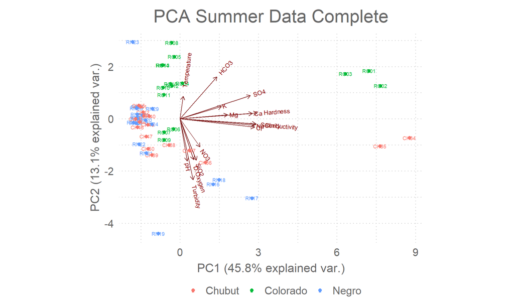

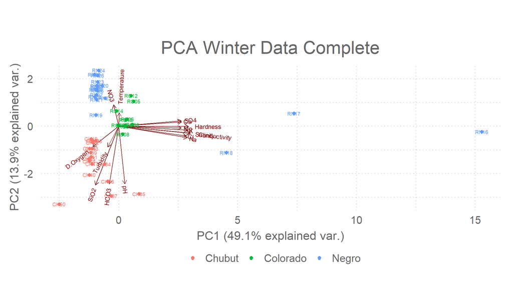

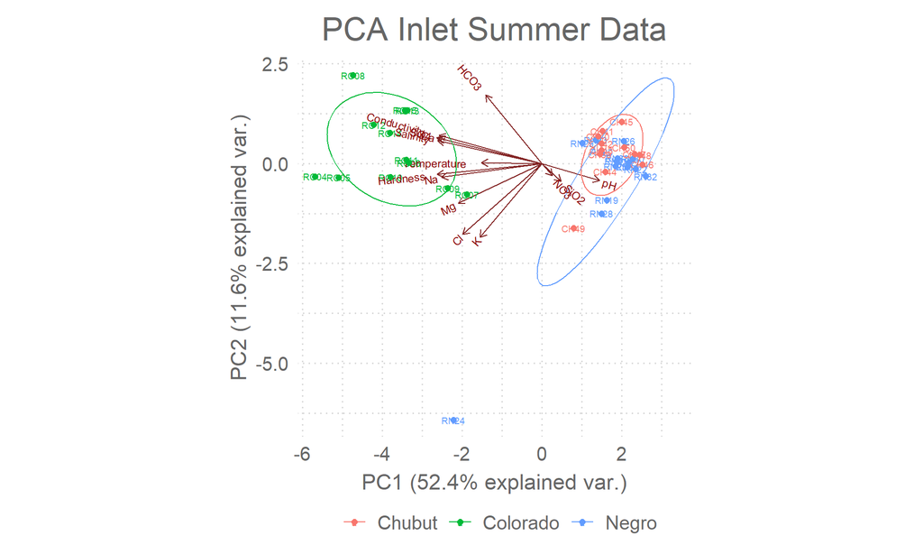

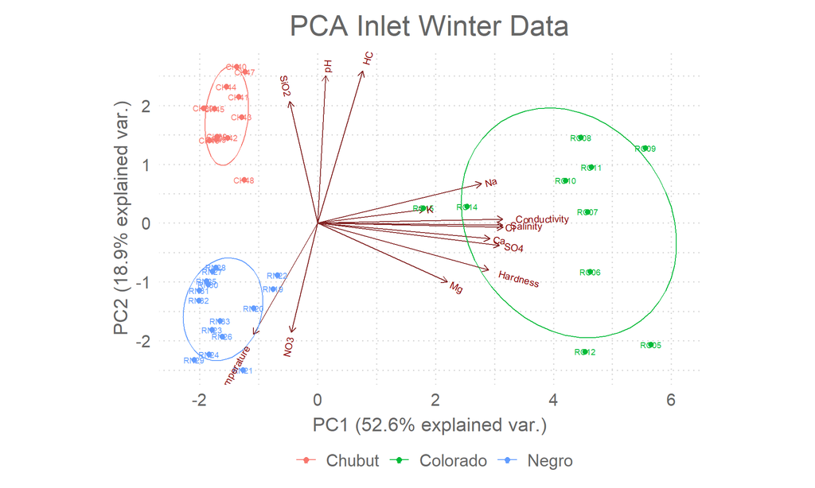

# **Piper Diagrams**

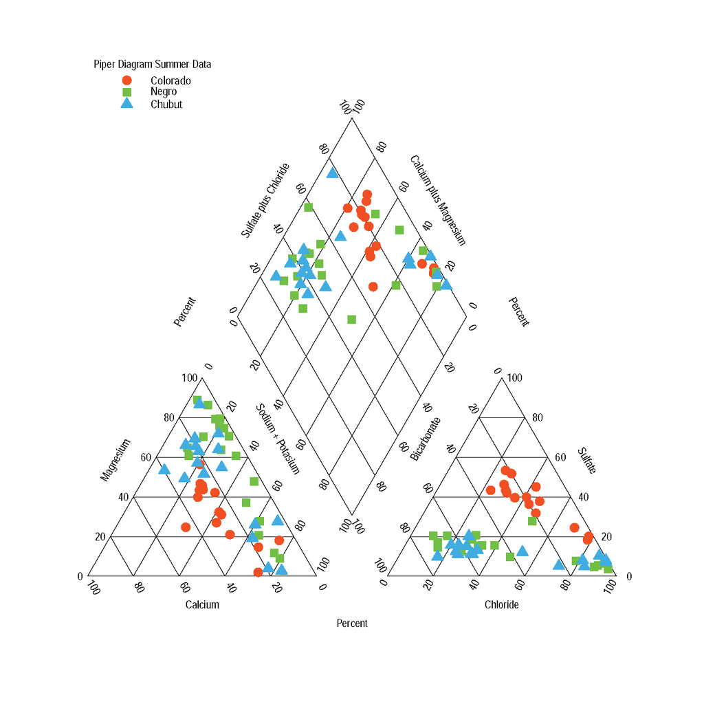

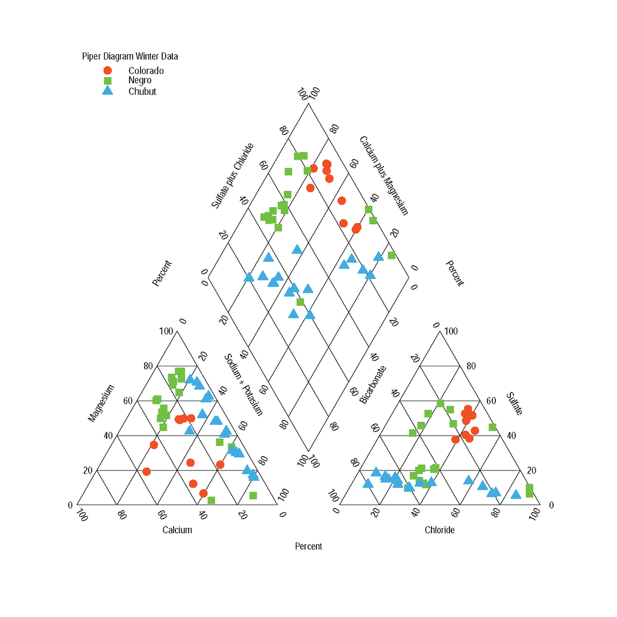